# Analysis of Phenotypic Data from Human Pancreatic Islets

PI Charlotte Ling, Lund University

Nikolay Oskolkov, SciLifeLab, NBIS Long Term Support, nikolay.oskolkov@scilifelab.se

January 17, 2020

Abstract

Here we will use the available phenotypic data from Human Pancreatic Islets from individuals with and without Type 2 Diabetes (T2D) and perform diebetes status linear predictive analysis with PLS-DA model on 110 manually selected individuals with most reliable phenotypic information.

### The List of 110 Selected Individuals

All the analysis will be performed on the 110 individuals which were selected based on multiple criteria such as 1) they are either normo-glycimic or hyper-glycemic / T2D individuals, 2) they have information from all the 4 OMICS (methylation, transcriptomics, phenotypes, genotypes), 3) they all fall within the same age category, and a few other minor criteria. Now we will read the list of those 110 individuals and display a few of them:

```r
set.seed(1)
selected_ind<-scan("OVERLAPPING_110_SAMPLES_4OMICS.txt", what = "charater")
selected_ind<-paste0("ID",selected_ind)
print(head(selected_ind, 20))
```

```
##  [1] "ID1"  "ID3"  "ID4"  "ID6"  "ID8"  "ID10" "ID14" "ID19" "ID21" "ID30"
## [11] "ID32" "ID34" "ID35" "ID36" "ID38" "ID39" "ID44" "ID46" "ID55" "ID58"
```

```r
print(tail(selected_ind, 20))
```

```
##  [1] "ID136" "ID156" "ID160" "ID165" "ID168" "ID172" "ID175" "ID182"
##  [9] "ID183" "ID191" "ID194" "ID200" "ID209" "ID210" "ID214" "ID217"
## [17] "ID221" "ID228" "ID263" "ID273"
```

### Checking Human Islets Phenotypes

We will start with the analysis of phenotypes available from approximately 300 Human Panctreatic Islets in order to check the relation between the phenotypes. Later this information will be taken into account when we do batch-effects correction. The phenotype file below was provided by Human Tissue Lab (HTL) from Lund University Diabetes Center (LUDC), it includes phenotypic information from approximately 300 pancreatic islets donors. Not all of them will overlap with the methylation array, RNAseq and genotyping array samples but we still will use the info from all available donors in order to establish how phenotypes are correlated with each other. We start with reading the file and removing non-relevant phenotypes:

- HTL_donor_ID: Human Tissue Lab Donor ID)
- NICS_donor_ID: Uppsala donor ID
- Birth: redundant, captured by Age variable
- HbA1c_mmol_mol: redundant, captured by HbA1c_perc
- Blood_group: unlikely to be related to Type 2 Diabetes
- Non_diabetic: redundant, captured by T2D variable
- GAD: not related to T2D
- Gestational: appropriate only for females, will be correlated with Sex
- Date_isolated_islets: unlikely to be related to Type 2 Diabetes
- Date_recieved_islets: unlikely to be related to Type 2 Diabetes
- Islet_equivalences: unlikely to be related to Type 2 Diabetes
- Diabetes_treatment: too sparse information

We will also add information about Methylation EPIC Array batches and RNAseq batches (old vs. new chemistry) in order to see what phenotypes the batches correlate with. This is a potential danger if the batches happen to correlate with valuables phenotypes like T2D or HbA1c. As a control of noise level we will introduce a random variable, we will use it to check later how much of phenotypic variation can be explained by chance.

```r
htl<-read.csv("htl_donors.csv",header=TRUE,check.names=FALSE)
htl$HTL_donor_ID<-paste0("ID",htl$HTL_donor_ID)
phen_meth_batch<-read.delim("phenotypes_islets.txt",header=TRUE,row.names=1,check.names=FALSE,sep="\t")
htl$Meth_Batch<-phen_meth_batch$batch[match(as.character(htl$HTL_donor_ID),rownames(phen_meth_batch))]
htl$Meth_Batch[is.na(htl$Meth_Batch)]<-21
phen_rnaseq_batch<-read.delim("phen_rnaseq_batch.txt",header=TRUE,row.names=1,check.names=FALSE,sep="\t")
htl$RNA_Batch<-phen_rnaseq_batch$batch[match(as.character(htl$HTL_donor_ID),rownames(phen_rnaseq_batch))]
htl$Random<-log(sample(dim(htl)[1]))
rownames(htl)<-htl$HTL_donor_ID

htl$HTL_donor_ID<-NULL
htl$NICS_donor_ID<-NULL
htl$Birth<-NULL
htl$HbA1c_mmol_mol<-NULL
htl$Blood_group<-NULL
htl$Non_diabetic<-NULL
htl$GAD<-NULL
htl$Gestational<-NULL
htl$Date_isolated_islets<-NULL
htl$Date_recieved_islets<-NULL
htl$Islet_equivalences<-NULL
htl$Diabetes_treatment<-NULL
head(htl)
```

```
##     Gender Age  BMI HbA1c_perc T2D Stimulatory_index Purity_perc
## ID1   Male  68 24.7        5.8   0               9.6          75
## ID2   Male  55 24.7         NA   0              10.2          90
## ID3 Female  45 23.9        5.4   0               3.6          70
## ID4 Female  61 27.7         NA   0              14.9          80
## ID5 Female  69 17.6         NA   0              10.9          37
## ID6   Male  67 28.4        5.5   0               1.9          95
##     Days_cultured Meth_Batch RNA_Batch   Random
## ID1             5          1  old_chem 5.117994
## ID2             8         21  old_chem 4.859812
## ID3             3          1  old_chem 5.598422
## ID4             5         21  old_chem 5.231109
## ID5             2         21  old_chem 4.442651
## ID6             2          1  old_chem 5.624018
```

For convenience we will rename HbA1c_perc to HbA1c, Stimulatory_index to SI, Purity_perc to Purity, Days_cultured to DIC. We will also assign donors with HbA1c > 6.5 to diabetics and balance the data set a bit better in this way.

```r
names(htl)[names(htl)=="HbA1c_perc"]<-"HbA1c"
names(htl)[names(htl)=="Stimulatory_index"]<-"SI"
names(htl)[names(htl)=="Purity_perc"]<-"Purity"
names(htl)[names(htl)=="Days_cultured"]<-"DIC"
htl$T2D<-ifelse( ((is.na(htl$T2D)==FALSE & htl$T2D==1) | (is.na(htl$HbA1c)==FALSE  & htl$HbA1c>6.5)), 1, 0)
head(htl)
```

```
##     Gender Age  BMI HbA1c T2D   SI Purity DIC Meth_Batch RNA_Batch
## ID1   Male  68 24.7   5.8   0  9.6     75   5          1  old_chem
## ID2   Male  55 24.7    NA   0 10.2     90   8         21  old_chem
## ID3 Female  45 23.9   5.4   0  3.6     70   3          1  old_chem
## ID4 Female  61 27.7    NA   0 14.9     80   5         21  old_chem
## ID5 Female  69 17.6    NA   0 10.9     37   2         21  old_chem
## ID6   Male  67 28.4   5.5   0  1.9     95   2          1  old_chem
##       Random
## ID1 5.117994
## ID2 4.859812
## ID3 5.598422
## ID4 5.231109
## ID5 4.442651
## ID6 5.624018
```

```r
for(i in 1:ncol(htl))
{
  if(length(levels(factor(htl[,i]))) > 2)
  {
    htl[,i]<-as.numeric(as.character(htl[,i]))
  }
  else
  {
    htl[,i]<-as.factor(htl[,i])
  }
}
```

Now we are going to select the 110 individuals with overlapping OMICs and keep only those individuals for further downstream analysis:

```r
htl<-htl[match(selected_ind,rownames(htl)),]
head(htl)
```

```
##      Gender Age  BMI HbA1c T2D   SI Purity DIC Meth_Batch RNA_Batch
## ID1    Male  68 24.7   5.8   0  9.6     75   5          1  old_chem
## ID3  Female  45 23.9   5.4   0  3.6     70   3          1  old_chem
## ID4  Female  61 27.7    NA   0 14.9     80   5         21  old_chem
## ID6    Male  67 28.4   5.5   0  1.9     95   2          1  old_chem
## ID8    Male  51 27.0   4.3   0 37.3     75   2         14  old_chem
## ID10 Female  60 26.1    NA   0  5.6     75   2         21  old_chem
##        Random
## ID1  5.117994
## ID3  5.598422
## ID4  5.231109
## ID6  5.624018
## ID8  4.369448
## ID10 3.610918
```

Now let us calculate pair-wise linear regression for the phenotypes and extract the adjusted R squared information which is equaivalent to the fraction of variation in the response variable explained by the predictor variable. In case the response variable is a factor, we will be using logistic regression (Generalized Linear Model, GLM, with family = “binomial”) and calculate the adjusted R suared as:

$$R^2_{adj} = 1 - \frac{\rm{Residual Deviance}}{\rm{Null Deviance}}$$

```r
htl_adj_r_squared<-matrix(NA,ncol=ncol(htl),nrow=ncol(htl))
for(i in 1:ncol(htl))
{
  print(i)
  for(j in 1:ncol(htl))
  {
    if(typeof(htl[,i])=="double" & (typeof(htl[,j])=="double" | typeof(htl[,j])=="integer"))
    {
      model<-suppressWarnings(lm(htl[,i]~htl[,j]))
      htl_adj_r_squared[j,i]<-suppressWarnings(summary(model)$adj.r.squared)
    }
    if(typeof(htl[,i])=="integer" & typeof(htl[,j])=="double")
    {
      model<-suppressWarnings(lm(htl[,j]~htl[,i]))
      htl_adj_r_squared[j,i]<-suppressWarnings(summary(model)$adj.r.squared)
    }
    if(typeof(htl[,i])=="integer" & typeof(htl[,j])=="integer")
    {
      model<-suppressWarnings(glm(htl[,i]~htl[,j],family="binomial"))
      htl_adj_r_squared[j,i]<-1-model$deviance/model$null.deviance
    }
  }
}
```

```
## [1] 1
## [1] 2
## [1] 3
## [1] 4
## [1] 5
## [1] 6
## [1] 7
## [1] 8
## [1] 9
## [1] 10
## [1] 11
```

```r
htl_adj_r_squared<-as.data.frame(htl_adj_r_squared)
colnames(htl_adj_r_squared)<-colnames(htl)
rownames(htl_adj_r_squared)<-colnames(htl)
htl_adj_r_squared[htl_adj_r_squared<0]<-0
htl_adj_r_squared
```

```
##                  Gender         Age         BMI      HbA1c          T2D
## Gender     1.0000000000 0.000000000 0.000000000 0.00000000 6.709567e-05
## Age        0.0000000000 1.000000000 0.000000000 0.00000000 0.000000e+00
## BMI        0.0000000000 0.000000000 1.000000000 0.02101267 3.241738e-02
## HbA1c      0.0000000000 0.000000000 0.021012675 1.00000000 5.635442e-01
## T2D        0.0000608413 0.000000000 0.032417382 0.56354416 1.000000e+00
## SI         0.0047175889 0.000000000 0.000000000 0.01691996 4.099784e-03
## Purity     0.0000000000 0.000000000 0.000000000 0.00000000 0.000000e+00
## DIC        0.0000000000 0.011359304 0.000000000 0.03419322 7.579456e-02
## Meth_Batch 0.0000000000 0.005251804 0.000000000 0.00000000 0.000000e+00
## RNA_Batch  0.0022531214 0.000000000 0.000000000 0.00000000 2.053184e-02
## Random     0.0000000000 0.000000000 0.001175757 0.00000000 7.923939e-03
##                     SI      Purity         DIC  Meth_Batch  RNA_Batch
## Gender     0.004717589 0.000000000 0.000000000 0.000000000 0.00262000
## Age        0.000000000 0.000000000 0.011359304 0.005251804 0.00000000
## BMI        0.000000000 0.000000000 0.000000000 0.000000000 0.00000000
## HbA1c      0.016919962 0.000000000 0.034193217 0.000000000 0.00000000
## T2D        0.004099784 0.000000000 0.075794563 0.000000000 0.01798873
## SI         1.000000000 0.000000000 0.000000000 0.017228281 0.08353539
## Purity     0.000000000 1.000000000 0.067372444 0.004887090 0.04538269
## DIC        0.000000000 0.067372444 1.000000000 0.004515378 0.00000000
## Meth_Batch 0.017228281 0.004887090 0.004515378 1.000000000 0.05496894
## RNA_Batch  0.083535390 0.045382693 0.000000000 0.054968938 1.00000000
## Random     0.011848277 0.002161258 0.000000000 0.000000000 0.02205427
##                 Random
## Gender     0.000000000
## Age        0.000000000
## BMI        0.001175757
## HbA1c      0.000000000
## T2D        0.007923939
## SI         0.011848277
## Purity     0.002161258
## DIC        0.000000000
## Meth_Batch 0.000000000
## RNA_Batch  0.022054271
## Random     1.000000000
```

Now we can plot the heatmap of the adjusted R squared statistics and check how phenotypes and batches are related to each other:

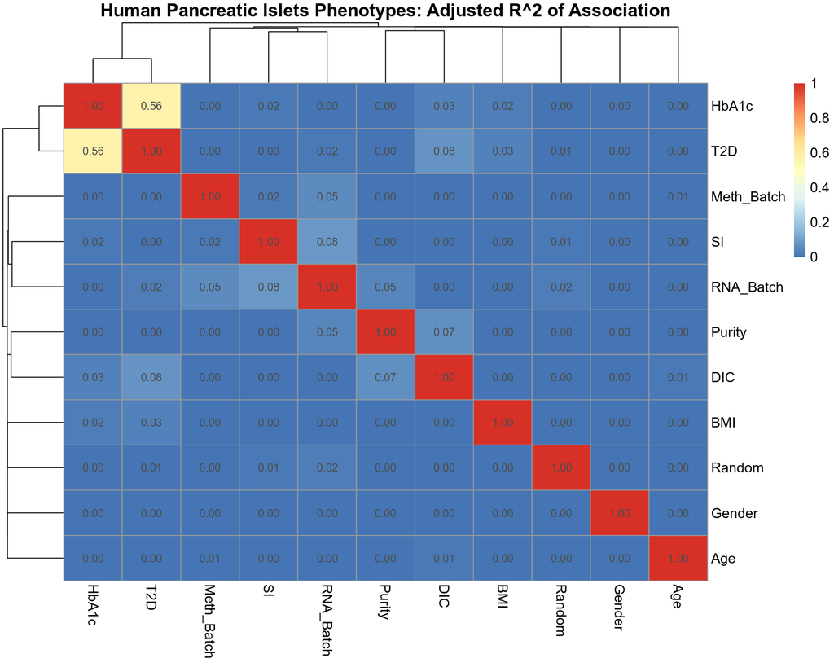

```r
library("pheatmap")
pheatmap(htl_adj_r_squared, display_numbers=TRUE, fontsize=12, main="Human Pancreatic Islets Phenotypes: Adjusted R^2 of Association")
```

### Preparing Phenotypes for T2D Prediction

Now let us select phenotypes that can be utilized in practice for predicting T2D. Obviously, Purity and DIC are technical variables that are good to have for the exploratory data analysis that we have done, but they are not to be used in the real world for predicting T2D despite DIC is moderately correlated with T2D due to technical reasons. For the same reason we exclude Meth_Batch, RNA_Batch and Random variables. HbA1c should be excluded because the T2D status is largely based on HbA1c values, so T2D and HbA1c are basically the same variable, so HbA1c should not be used for predicting T2D. Therefore we end up with just four variables: Age, Gender, SI and BMI. Let us merge them into an X matrix for future running PCA on it:

```r
library("mixOmics")
X<-subset(htl,select=c("Age","Gender","BMI","SI"))
X$Gender<-ifelse(as.character(X$Gender)=="Male",1,0)
X[1:10,1:4]
```

```
##      Age Gender  BMI   SI
## ID1   68      1 24.7  9.6
## ID3   45      0 23.9  3.6
## ID4   61      0 27.7 14.9
## ID6   67      1 28.4  1.9
## ID8   51      1 27.0 37.3
## ID10  60      0 26.1  5.6
## ID14  73      1 26.2  2.7
## ID19  61      1 24.7  1.6
## ID21  55      0 22.5  2.5
## ID30  58      1 26.2  2.6
```

```r
dim(X)
```

```
## [1] 110   4
```

Next we will impute missing values with the median across the samples for each phenotype:

```r
for(i in 1:ncol(X))
{
  X[,i][is.na(X[,i])]<-median(X[,i],na.rm=TRUE)
}
```

In principal, we need to standardize each phenotype as the values from different phenotypes are on different scales. However, this usually brings negative values and hence technical complications and less transparency to the analysis. Another way to deal with this problem is to log-transform each phenotype which is equaivalent to a mild normalization / harmonization of the phenotypic values and bringing them to the same scale:

```r
X$Age<-log10(as.numeric(X$Age)+1)
X$BMI<-log10(as.numeric(X$BMI)+1)
X$SI<-log10(as.numeric(X$SI)+1)
X[1:10,1:4]
```

```
##           Age Gender      BMI        SI
## ID1  1.838849      1 1.409933 1.0253059
## ID3  1.662758      0 1.396199 0.6627578
## ID4  1.792392      0 1.457882 1.2013971
## ID6  1.832509      1 1.468347 0.4623980
## ID8  1.716003      1 1.447158 1.5831988
## ID10 1.785330      0 1.432969 0.8195439
## ID14 1.869232      1 1.434569 0.5682017
## ID19 1.792392      1 1.409933 0.4149733
## ID21 1.748188      0 1.371068 0.5440680
## ID30 1.770852      1 1.434569 0.5563025
```

```r
dim(X)
```

```
## [1] 110   4
```

Now we are ready to do PCA on the phenotypic values:

```r
pca.phen<-pca(X, ncomp=4, center=TRUE, scale=TRUE)
pca.phen
```

```
## Eigenvalues for the first 4 principal components, see object$sdev^2:
##       PC1       PC2       PC3       PC4
## 1.1778854 1.0290570 0.9578196 0.8352380
##
## Proportion of explained variance for the first 4 principal components, see object$explained_variance:
##       PC1       PC2       PC3       PC4
## 0.2944714 0.2572642 0.2394549 0.2088095
##
## Cumulative proportion explained variance for the first 4 principal components, see object$cum.var:
##       PC1       PC2       PC3       PC4
## 0.2944714 0.5517356 0.7911905 1.0000000
##
##  Other available components:
##  --------------------
##  loading vectors: see object$rotation
```

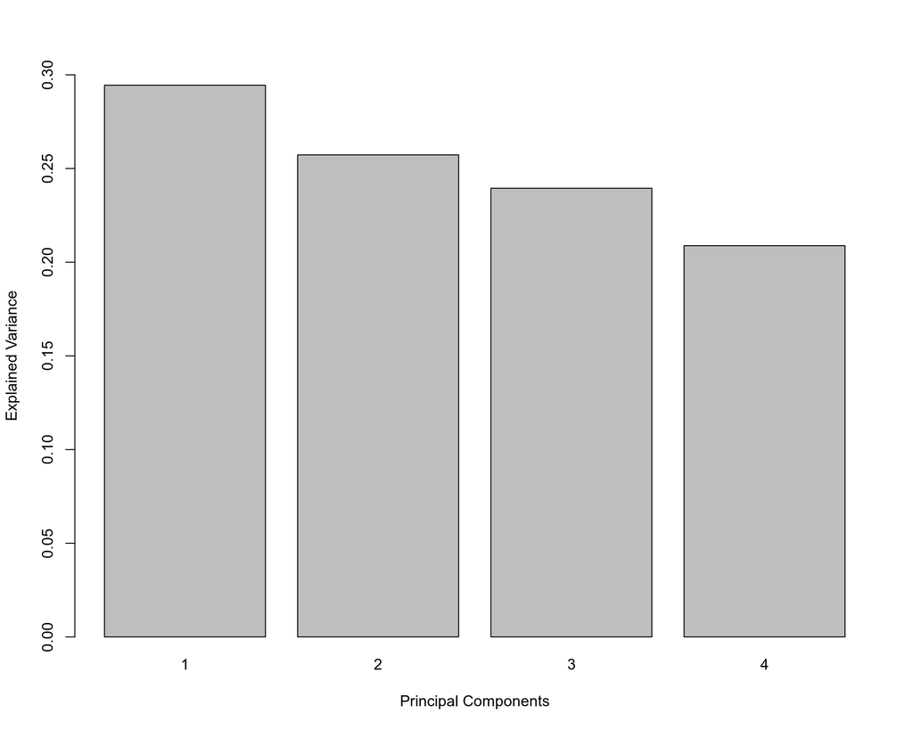

```r
plot(pca.phen,ylim=c(0,0.3))
```

The PCA shows that about 50% of the total variance is explained by the first 2 principal components. We will visualize PC1 vs. PC2 dependence coloring samples according to their diabetes status and gender:

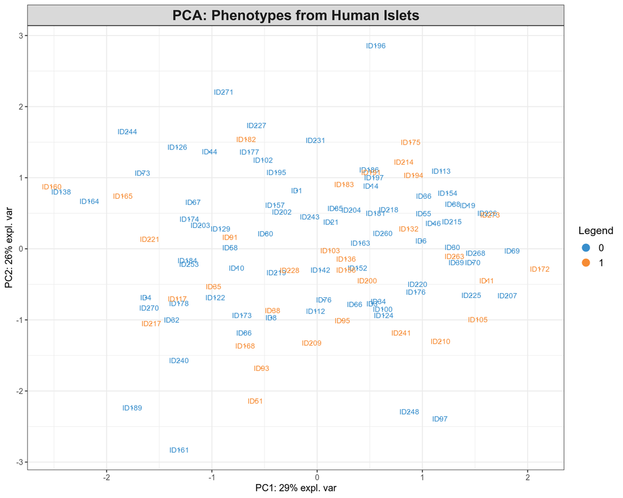

```r
plotIndiv(pca.phen,group=as.factor(htl$T2D),ind.names=TRUE,ellipse=FALSE,legend=TRUE,title="PCA: Phenotypes from Human Islets")
```

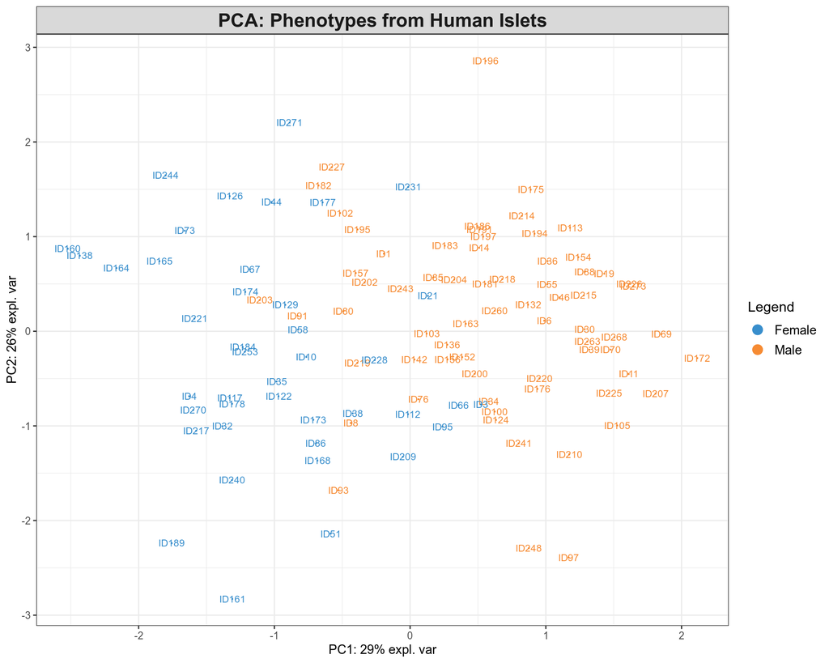

```r
plotIndiv(pca.phen,group=as.factor(htl$Gender),ind.names=TRUE,ellipse=FALSE,legend=TRUE,title="PCA: Phenotypes from Human Islets")
```

We see obvious clustering by Gender but not by T2D on genome-wide level. To understand which variables drive the PCA plot let us display the loadings for PC1 and PC2:

```
## 'ndisplay' value is larger than the number of selected variables! It has been reseted to 4 for block 1
```

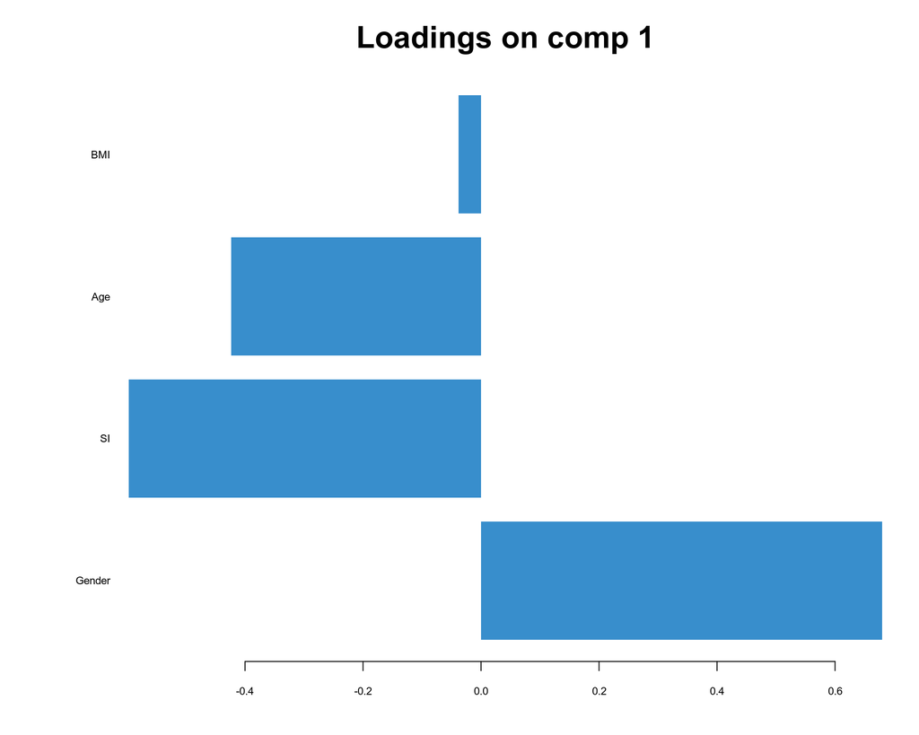

```r
plotLoadings(pca.phen,comp=1,method='median',contrib='max',ndisplay=20)
```

```r
head(sort(abs(pca.phen$loadings$X[,"PC1"]),decreasing=TRUE),20)
```

```
##     Gender         SI        Age        BMI
## 0.67997798 0.59721851 0.42371533 0.03775335
```

```
## 'ndisplay' value is larger than the number of selected variables! It has been reseted to 4 for block 1
```

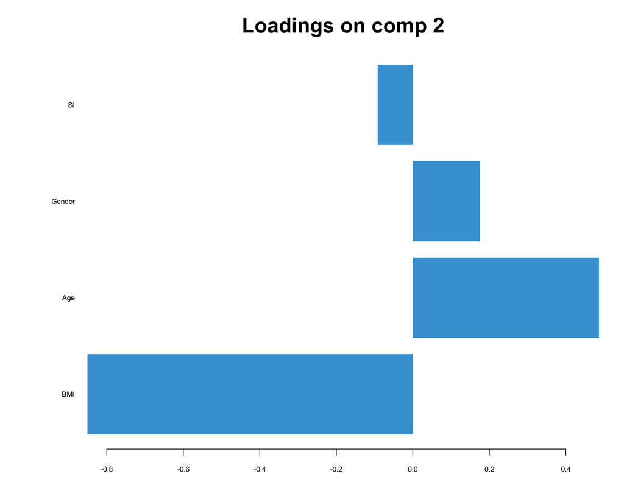

```r
plotLoadings(pca.phen,comp=2,method='median',contrib='max',ndisplay=20)
```

```r
head(sort(abs(pca.phen$loadings$X[,"PC2"]),decreasing=TRUE),20)
```

```
##        BMI        Age     Gender         SI
## 0.85080572 0.48679828 0.17503896 0.09229534
```

We conclude that the main variation in the data comes from Gender and BMI variables.

### PLS-DA Analysis of Phenotypic Data

Now we will perform PLS-DA analysis, for this purpose we are going to construct the X and Y matrices in order to maximize their covariance, cov(X,Y), the X matrix has been already built in the previous section:

```r
gc()
```

```
##           used  (Mb) gc trigger  (Mb) max used  (Mb)
## Ncells 1931774 103.2    3921187 209.5  3921187 209.5
## Vcells 3446075  26.3    8388608  64.0  6207474  47.4
```

```r
library("mixOmics")
head(X)
```

```
##           Age Gender      BMI        SI
## ID1  1.838849      1 1.409933 1.0253059
## ID3  1.662758      0 1.396199 0.6627578
## ID4  1.792392      0 1.457882 1.2013971
## ID6  1.832509      1 1.468347 0.4623980
## ID8  1.716003      1 1.447158 1.5831988
## ID10 1.785330      0 1.432969 0.8195439
```

```r
Y<-as.factor(as.character(htl$T2D))
summary(Y)
```

```
##  0  1
## 78 32
```

We have approximately 29% of T2D individuals which is not crazy unbalanced, so there is a hope that the model does not learn only the majority class. Important to mention that a very naive / stupid classifier that predicts Non-T2D for any given individual should thus achieve 71% accuracy of classification. So our PLS-DA model should be better than the naive classifier and outperform the lower threshold of 71%.

```r
my_folds=2
my_nrepeat=10
my_progressBar=FALSE
my_cpus=1
```

```r
gc()
```

```
##           used  (Mb) gc trigger  (Mb) max used  (Mb)
## Ncells 1932067 103.2    3921187 209.5  3921187 209.5
## Vcells 3447205  26.4    8388608  64.0  6207474  47.4
```

```r
phen_plsda.perf<-plsda(X, Y, ncomp=4)

ptm<-proc.time()
perf.plsda<-perf(phen_plsda.perf, validation='Mfold', folds=my_folds, progressBar=my_progressBar, nrepeat=my_nrepeat)
proc.time()-ptm
```

```
##    user  system elapsed
##   1.896   0.000   1.896
```

```r
perf.plsda
```

```
##
## Call:
##  perf.mixo_plsda(object = phen_plsda.perf, validation = "Mfold", folds = my_folds, nrepeat = my_nrepeat, progressBar = my_progressBar)
##
##  Main numerical outputs:
##  --------------------
##  Error rate (overall or BER) for each component and for each distance: see object$error.rate
##  Error rate per class, for each component and for each distance: see object$error.rate.class
##  Prediction values for each component: see object$predict
##  Classification of each sample, for each component and for each distance: see object$class
##  AUC values: see object$auc if auc = TRUE
##
##  Visualisation Functions:
##  --------------------
##  plot
```

```r
head(perf.plsda$error.rate)
```

```
## $overall
##        max.dist centroids.dist mahalanobis.dist
## comp1 0.3036364      0.3981818        0.3981818
## comp2 0.3118182      0.4100000        0.4072727
## comp3 0.3036364      0.4172727        0.4227273
## comp4 0.3045455      0.4118182        0.4127273
##
## $BER
##        max.dist centroids.dist mahalanobis.dist
## comp1 0.4840946      0.4263622        0.4263622
## comp2 0.4788061      0.4236378        0.4217147
## comp3 0.4693510      0.4315304        0.4362981
## comp4 0.4718349      0.4488782        0.4485978
```

```r
head(perf.plsda$error.rate.class)
```

```
## $max.dist
##       comp1      comp2      comp3      comp4
## 0 0.0525641 0.07948718 0.07307692 0.07179487
## 1 0.9156250 0.87812500 0.86562500 0.87187500
##
## $centroids.dist
##       comp1     comp2     comp3     comp4
## 0 0.3589744 0.3910256 0.3974359 0.3602564
## 1 0.4937500 0.4562500 0.4656250 0.5375000
##
## $mahalanobis.dist
##       comp1     comp2     comp3     comp4
## 0 0.3589744 0.3871795 0.4038462 0.3628205
## 1 0.4937500 0.4562500 0.4687500 0.5343750
```

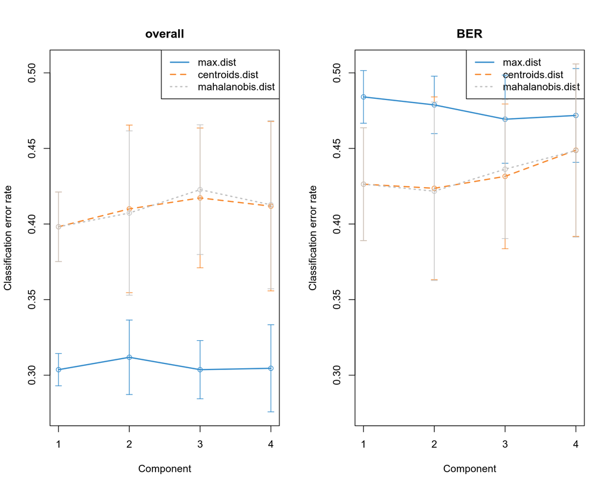

```r
plot(perf.plsda,overlay='dist',sd=TRUE)
```

We can see that BER Mahalanobis distance seems to reach their plateau or weak minimum at ncomp=2, so we will use 2 PLS components for further PLS-DA analysis.

```r
gc()
```

```
##           used  (Mb) gc trigger  (Mb) max used  (Mb)
## Ncells 1981898 105.9    3921187 209.5  3921187 209.5
## Vcells 3578332  27.4    8388608  64.0  6207474  47.4
```

```r
phen_plsda<-plsda(X, Y, ncomp=2)
phen_plsda$explained_variance
```

```
## $X
##    comp 1    comp 2
## 0.2450981 0.2687532
##
## $Y
##    comp 1    comp 2
## 1.0000000 0.9302999
```

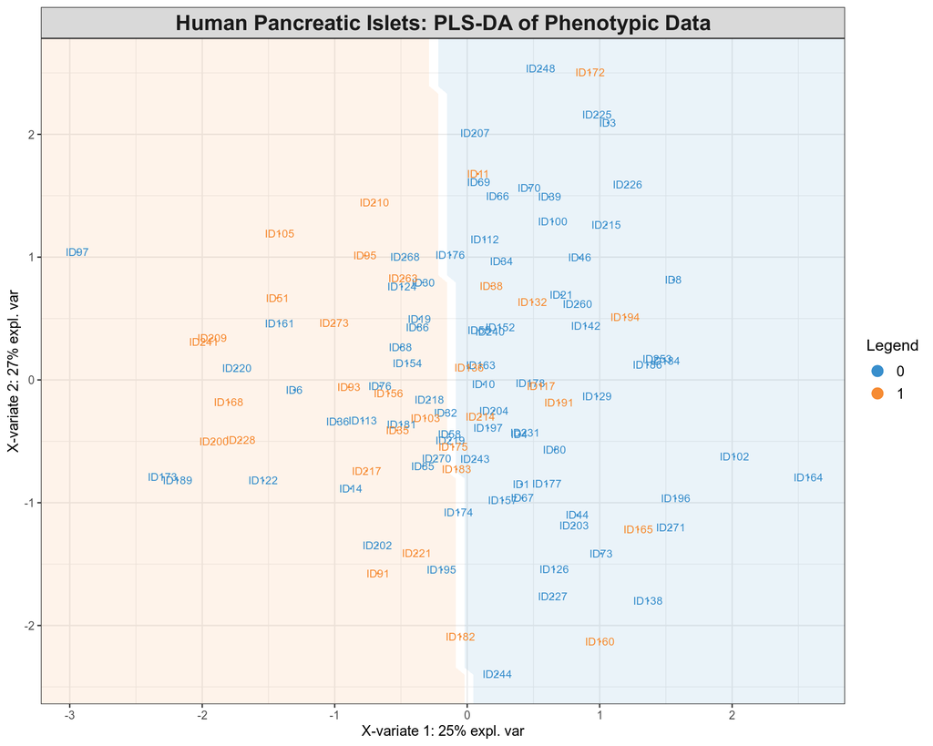

```r
background = background.predict(phen_plsda, comp.predicted=2, dist = "mahalanobis.dist")
plotIndiv(phen_plsda, comp=c(1,2), group=Y, ind.names=TRUE, ellipse=FALSE, background=background, legend=TRUE, title="Human Pancreatic Islets: PLS-DA of Phenotypic Data")
```

We do not see an obvious seperation between T2D and NonT2D individuals, meaning that the clinical phenotypes are not really good predictors of T2D. Plotting the loadings of the two PLS components we can see which phenotypes are responsible for the linear separation of the T2D and non-T2D individuals:

```
## 'ndisplay' value is larger than the number of selected variables! It has been reseted to 4 for block X
```

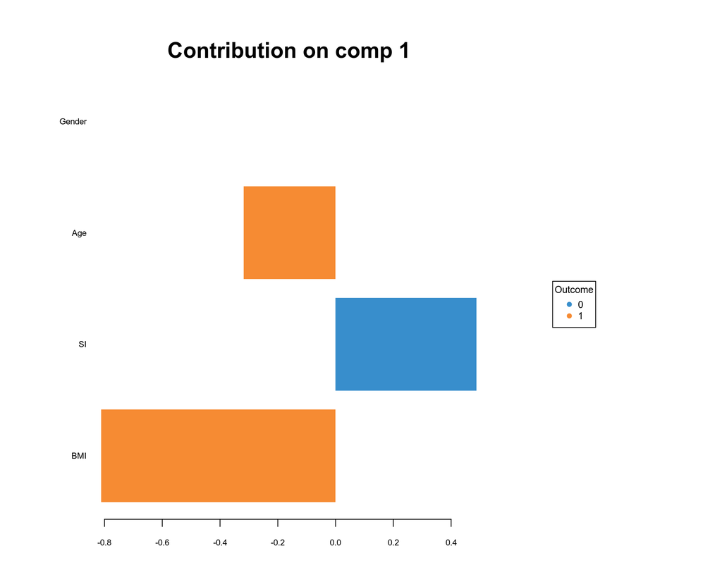

```r
plotLoadings(phen_plsda, comp=1, method='median', contrib='max', ndisplay=20)
```

```r
head(sort(abs(phen_plsda$loadings$X[,"comp1"]),decreasing=TRUE),10)
```

```
##        BMI         SI        Age     Gender
## 0.81185845 0.48800703 0.31866925 0.03442243
```

```
## 'ndisplay' value is larger than the number of selected variables! It has been reseted to 4 for block X
```

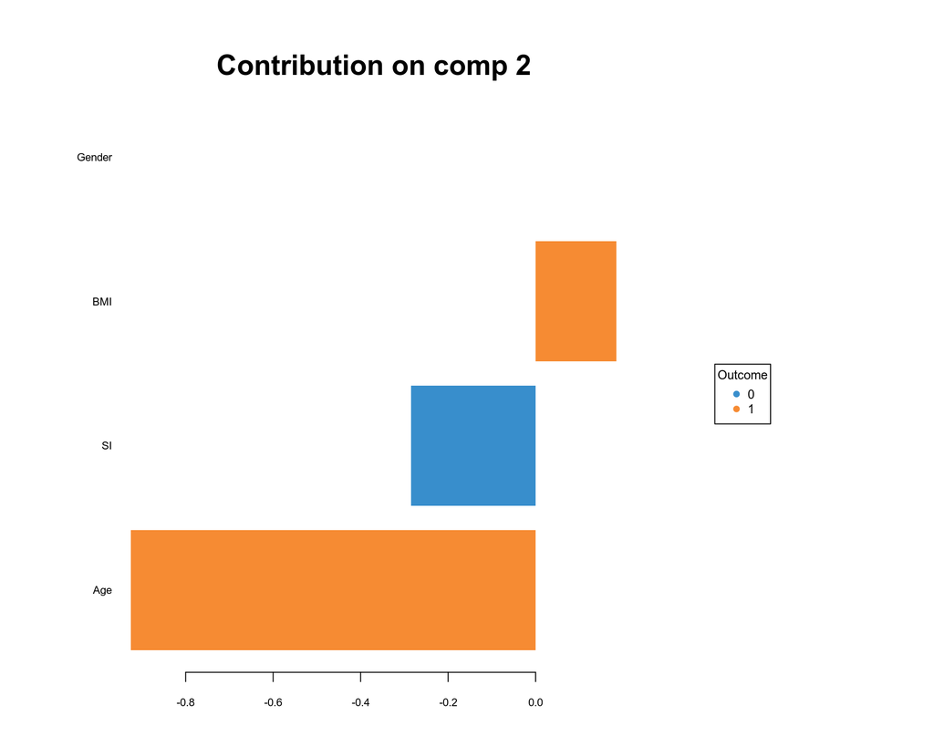

```r
plotLoadings(phen_plsda, comp=2, method='median', contrib='max', ndisplay=20)
```

```r
head(sort(abs(phen_plsda$loadings$X[,"comp2"]),decreasing=TRUE),10)
```

```
##       Age        SI       BMI    Gender
## 0.9255174 0.2851133 0.1848098 0.1672525
```

We conclude that BMI and Age seem to be primarily responsible for T2D status prediction which makes a lot of sense.

### Predicting T2D Status from sPLS-DA Model

Finally we will randomly split the phenotypic data set into training (80% of samples) and validation (20% of samples) sets. This is needed to validate predictions of PLS-DA trained on the training data set.

```r
gc()
```

```
##           used  (Mb) gc trigger  (Mb) max used  (Mb)
## Ncells 1996399 106.7    3921187 209.5  3921187 209.5
## Vcells 3613935  27.6    8388608  64.0  8388608  64.0
```

```r
N_repeat<-100
comp1_acc<-vector()
comp2_acc<-vector()
for(k in 1:N_repeat)
{
  print(paste0("Working with split No.", k))
  gc()
  set.seed(k+100)
  test_samples<-rownames(X)[sample(1:length(rownames(X)),round(length(rownames(X))*0.2))]
  train_samples<-rownames(X)[!rownames(X)%in%test_samples]

  X.train<-X[match(train_samples,rownames(X)),]
  X.test<-X[match(test_samples,rownames(X)),]
  Y.train<-as.factor(as.character(htl[match(train_samples,rownames(htl)),]$T2D))
  Y.test<-as.factor(as.character(htl[match(test_samples,rownames(htl)),]$T2D))

  plsda.phen.train<-plsda(X.train, Y.train, ncomp=2)

  plsda.phen.predict<-predict(plsda.phen.train, X.test, dist='mahalanobis.dist')

  print(table(plsda.phen.predict$class$mahalanobis.dist[,1],Y.test))
  acc1<-round((sum(diag(table(plsda.phen.predict$class$mahalanobis.dist[,1],Y.test)))/sum(table(plsda.phen.predict$class$mahalanobis.dist[,1],Y.test)))*100)
  print(paste0("Classification Accuracy from PLS Component 1: ", acc1))
  print(table(plsda.phen.predict$class$mahalanobis.dist[,2],Y.test))
  acc2<-round((sum(diag(table(plsda.phen.predict$class$mahalanobis.dist[,2],Y.test)))/sum(table(plsda.phen.predict$class$mahalanobis.dist[,2],Y.test)))*100)
  print(paste0("Classification Accuracy from PLS Component 2: ", acc2))

  comp1_acc<-append(comp1_acc,acc1)
  comp2_acc<-append(comp2_acc,acc2)
  print("***********************************************************")
}
```

```
## [1] "Working with split No.1"
##    Y.test
##     0 1
##   0 9 3
##   1 5 5
## [1] "Classification Accuracy from PLS Component 1: 64"
##    Y.test
##     0 1
##   0 9 3
##   1 5 5
## [1] "Classification Accuracy from PLS Component 2: 64"
## [1] "***********************************************************"
## [1] "Working with split No.2"
##    Y.test
##     0 1
```

[output cut: 1185 more lines]

```r
write.table(comp1_acc,file="Comp1_PLS_Phen_Acc.txt",col.names=FALSE,row.names=FALSE,quote=FALSE,sep="\t")
write.table(comp2_acc,file="Comp2_PLS_Phen_Acc.txt",col.names=FALSE,row.names=FALSE,quote=FALSE,sep="\t")
```

```r
gc()
```

```
##           used  (Mb) gc trigger  (Mb) max used  (Mb)
## Ncells 2005025 107.1    3921187 209.5  3921187 209.5
## Vcells 3637356  27.8    8388608  64.0  8388608  64.0
```

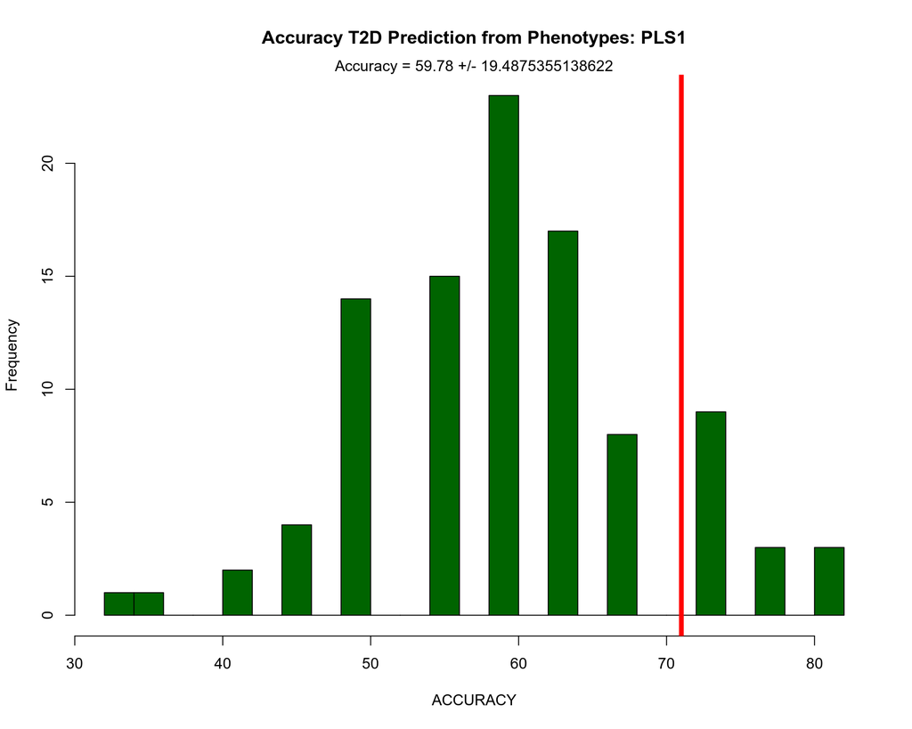

```r
comp1_acc_arch<-as.numeric(scan("Comp1_PLS_Phen_Acc.txt",what="character"))
comp2_acc_arch<-as.numeric(scan("Comp2_PLS_Phen_Acc.txt",what="character"))

#comp1_acc_arch<-c(comp1_acc,comp1_acc_arch)
#comp2_acc_arch<-c(comp2_acc,comp2_acc_arch)

hist(comp1_acc_arch,breaks=20,xlab="ACCURACY",main="Accuracy T2D Prediction from Phenotypes: PLS1",col="darkgreen")
abline(v=71,col="red",lwd=5)
mtext(paste0("Accuracy = ",mean(comp1_acc_arch)," +/- ",2*sd(comp1_acc_arch)))
```

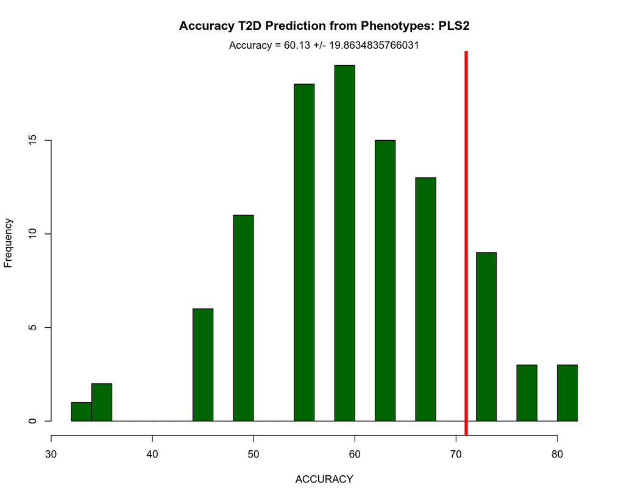

```r
hist(comp2_acc_arch,breaks=20,xlab="ACCURACY",main="Accuracy T2D Prediction from Phenotypes: PLS2",col="darkgreen")
abline(v=71,col="red",lwd=5)
mtext(paste0("Accuracy = ",mean(comp2_acc_arch)," +/- ",2*sd(comp2_acc_arch)))
```

We can compute how significantly different is the accuracy of the PLS-DA model compared to the naive 71% accuracy:

```r
gc()
```

```
##           used  (Mb) gc trigger  (Mb) max used  (Mb)
## Ncells 2007399 107.3    3921187 209.5  3921187 209.5
## Vcells 3642407  27.8    8388608  64.0  8388608  64.0
```

```r
sum(comp1_acc_arch<=71)/length(comp1_acc_arch)
```

```
## [1] 0.85
```

```r
sum(comp2_acc_arch<=71)/length(comp2_acc_arch)
```

```
## [1] 0.85
```

```r
rm(list=ls())
gc()
```

```
##           used  (Mb) gc trigger  (Mb) max used  (Mb)
## Ncells 2006435 107.2    3921187 209.5  3921187 209.5
## Vcells 3607711  27.6    8388608  64.0  8388608  64.0
```